# Airline Holiday Travel

Visualising passengers on flights departing Australia in the holiday period

Will Hore-Lacy

16/12/2018

## Premise

In Australia the Christmas holidays coincide with the summer school holidays so it is often a time people travel. The [Story Telling With Data challenge](https://www.storytellingwithdata.com/blog/2018/12/03/lets-visualize-the-holidays) prompted to me considered how airline travel patterns were different in this holiday period.

In the end I picked a problem that was too big for the official challenge time-frame but here’s what I came up with anyway…

## Results

In general the number of flights increased in the holiday period from 8276 to 9416 passengers per month, so the results are skewed towards an increases in passenger numbers, however there were some destinations the saw a reduction in the number of passengers. Because the absolute changes in passenger numbers were not large relative to the totals, the visualisaitons uses the change in passenger numbers between travel from February to November and the holiday period.

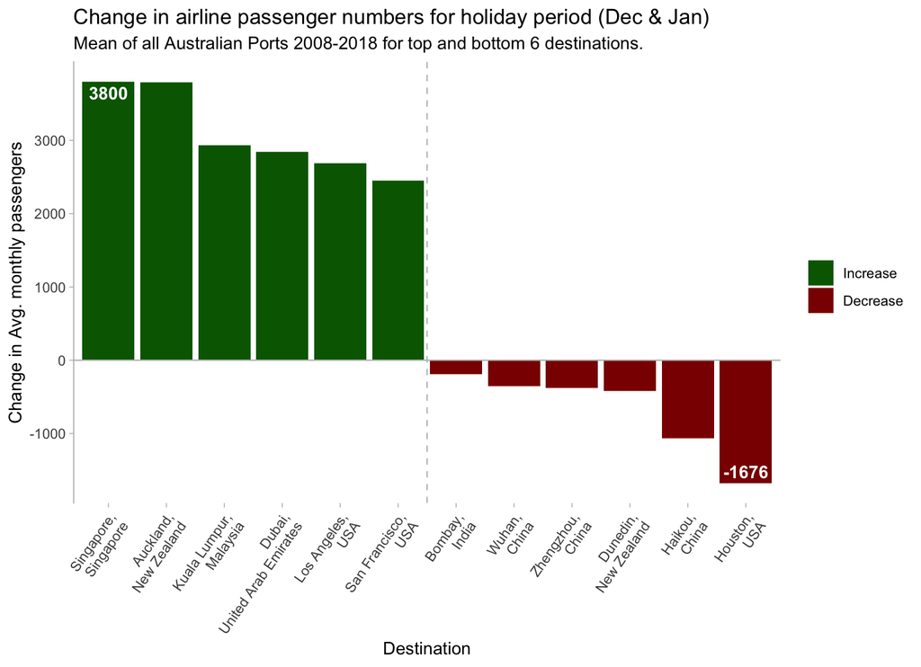

The same plot can be generated individually for each Australian port, however the map below can show the data for multiple pots at once and provides some extra information. The map shows the change in average monthly passengers in the December-January holiday period for origin destination pairs. Limited to the OD pairs with the top 12 increases and decreases.

[interactive chart not shown]

The first interesting pattern is that it appears that the data only show the first port visited rather than final destination, i.e. no locations in Europe but many flights to major interchange hubs. The second is that it shows a few differences in the destinations with large changes compared to the Australia-wide average data.

The top increased and decrease routes are highlighted in blue:

- Sydney to Auckland: 13359
- Brisbane to Osaka: -2637

## Data

Two data sets are used for the visualisation:

- [Flight data](https://data.gov.au/dataset/international-airlines-traffic-by-city-pairs)
  - city_pairs.csv (2008-2018 data only)
- [Airport data](https://openflights.org/data.html)
  - airports.dat

## Code

All code for this visualisation and my initial EDA can be found here:

- [Airline Holiday Travel on GitHub](https://github.com/WillCHL/airlineViz)